# 06_Main Analyses

Chiara Draxler

24 1 2022

#Introduction for working code:

0. Download the Code from Github. The new downloaded folder hc_switch_cccu-main contains the R project, Rmd Code, created data frames, knitted Html Code, Figures as .pdf and.jpg, Preregistered synthetic Code, and a folder to store the downloaded RData called RData.

Name the folder appropriately (when downloading the code from GitHub the folder will be hc_switch_cccu-main).

1. Download data from https://www.icpsr.umich.edu/web/DSDR/studies/37067/datadocumentation

Attention! The downloaded project from GitHub does not contain any data files!

–> Click on Download, then select R, then follow the login –> store data in the folder specific to the R project in an extra sub-folder called RData (i.e., hc_switch_cccu-main - > RData). If you downloaded the code from GitHub, the RData folder will be already in the hc_switch_cccu-main projects folder.

–> Within the RData folder store data for wave 1 in DS0001, for wave 2 in DS0002 and so on (i.e., hc_switch_cccu-main - > RData -> DS0001 ). If you downloaded the code from GitHub, the relevant folders will be already there.

–> name the Rdata files according to the wave:

Wave 1: 37067-0001-Data (i.e., hc_switch_cccu-main - > RData -> DS0001 -> 37067-0001-Data.rda )

Wave 2: 37067-0002-Data (i.e., hc_switch_cccu-main - > RData -> DS0002 -> 37067-0002-Data.rda )

Wave 3: 37067-0003-Data (i.e., hc_switch_cccu-main - > RData -> DS0003 -> 37067-0003-Data.rda )

Wave 4: 37067-0004-Data (i.e., hc_switch_cccu-main - > RData -> DS0004 -> 37067-0004-Data.rda )

–> attention to the .rda ending when loading the data into R!

2. make sure to install all relevant packages before running the code!

3. run the code according to the defined order beginning with 01_ (or 0 if you want to have a look at the synthetic data) and ending with 09_ so that all data frames are created appropriately
4. Run the Code :)

#1. Load Data

```r
load("cccu_MA.RData")
```

#2. Load Packages

```r
library(formr)
library(effects)
library(EValue)
library(lme4)
library(psych)
library(dplyr)
library(tidyverse)
library(marginaleffects)
options(scipen=999)
```

#3. Models

##3.1 Model 1: basic model

```r
m1 <- glmer(switch ~ hc + (1| CASEID), family = binomial, data = cccu_MA, control=glmerControl(optimizer="bobyqa"))

summary(m1)
```

```
## Generalized linear mixed model fit by maximum likelihood (Laplace
##   Approximation) [glmerMod]
##  Family: binomial  ( logit )
## Formula: switch ~ hc + (1 | CASEID)
##    Data: cccu_MA
## Control: glmerControl(optimizer = "bobyqa")
##
##      AIC      BIC   logLik deviance df.resid
##   2781.6   2800.3  -1387.8   2775.6     3784
##
## Scaled residuals:
##     Min      1Q  Median      3Q     Max
## -1.0109 -0.2473 -0.2323 -0.1500  3.0920
##
## Random effects:
##  Groups Name        Variance Std.Dev.
##  CASEID (Intercept) 3.267    1.807
## Number of obs: 3787, groups:  CASEID, 1993
##
## Fixed effects:
##             Estimate Std. Error z value             Pr(>|z|)
## (Intercept)  -2.4181     0.2204 -10.970 < 0.0000000000000002 ***
## hcnon_hc     -1.1611     0.1597  -7.272    0.000000000000355 ***
## ---
## Signif. codes:  0 '***' 0.001 '**' 0.01 '*' 0.05 '.' 0.1 ' ' 1
##
## Correlation of Fixed Effects:
##          (Intr)
## hcnon_hc 0.187
```

```r
confint(m1, method = "Wald", level = .997)
```

```
##                0.15 %    99.85 %
## .sig01             NA         NA
## (Intercept) -3.072274 -1.7639280
## hcnon_hc    -1.634967 -0.6872215
```

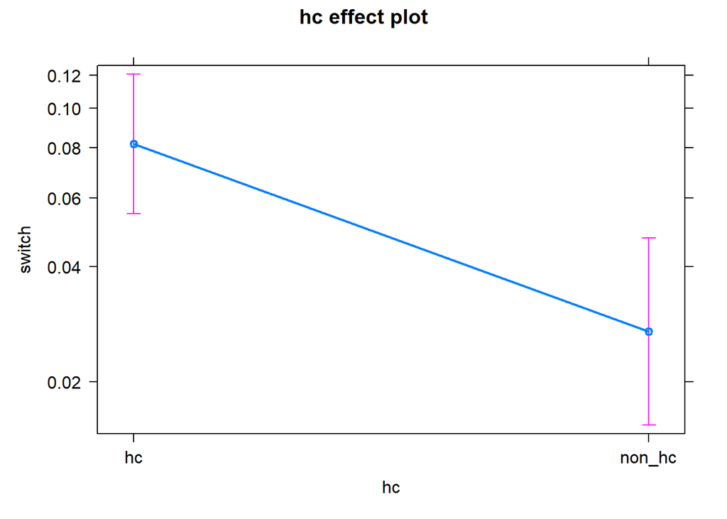

```r
plot(allEffects(m1))
```

##3.2 Model 2: including directly with contraceptive method associated predictors

```r
m2 <- glmer(switch ~ hc*contra_satis + (1| CASEID), family = binomial, data = cccu_MA, control=glmerControl(optimizer="bobyqa"))

summary(m2)
```

```
## Generalized linear mixed model fit by maximum likelihood (Laplace
##   Approximation) [glmerMod]
##  Family: binomial  ( logit )
## Formula: switch ~ hc * contra_satis + (1 | CASEID)
##    Data: cccu_MA
## Control: glmerControl(optimizer = "bobyqa")
##
##      AIC      BIC   logLik deviance df.resid
##   2739.0   2770.2  -1364.5   2729.0     3782
##
## Scaled residuals:
##     Min      1Q  Median      3Q     Max
## -1.5279 -0.2405 -0.2061 -0.1600  3.6568
##
## Random effects:
##  Groups Name        Variance Std.Dev.
##  CASEID (Intercept) 2.823    1.68
## Number of obs: 3787, groups:  CASEID, 1993
##
## Fixed effects:
##                       Estimate Std. Error z value       Pr(>|z|)
## (Intercept)             0.3235     0.4011   0.807          0.420
## hcnon_hc               -3.1116     0.6488  -4.796 0.000001618953 ***
## contra_satis           -0.7547     0.1174  -6.430 0.000000000128 ***
## hcnon_hc:contra_satis   0.5529     0.1863   2.968          0.003 **
## ---
## Signif. codes:  0 '***' 0.001 '**' 0.01 '*' 0.05 '.' 0.1 ' ' 1
##
## Correlation of Fixed Effects:
##             (Intr) hcnn_h cntr_s
## hcnon_hc    -0.586
## contra_sats -0.907  0.637
## hcnn_hc:cn_  0.569 -0.971 -0.611
```

```r
confint(m2, method = "Wald", level = .997)
```

```
##                               0.15 %    99.85 %
## .sig01                            NA         NA
## (Intercept)           -0.86696462958  1.5140162
## hcnon_hc              -5.03701812851 -1.1861356
## contra_satis          -1.10304145766 -0.4063511
## hcnon_hc:contra_satis  0.00006849479  1.1058256
```

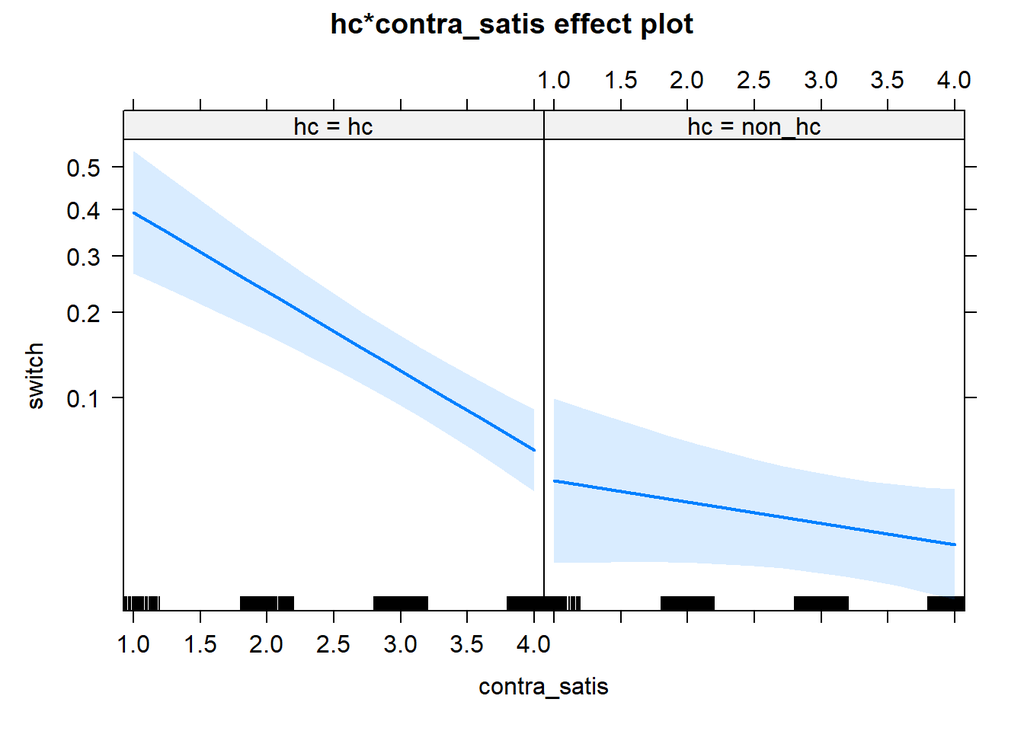

```r
plot(allEffects(m2))
```

##3.3 Model 3: including not directly with contraceptive method associated predictors

```r
m3 <- glmer(switch ~ hc * contra_satis +  hc * sexual_satisfaction + hc * sex_freq + (1| CASEID), family = binomial, data = cccu_MA, control=glmerControl(optimizer="bobyqa"))

summary(m3)
```

```
## Generalized linear mixed model fit by maximum likelihood (Laplace
##   Approximation) [glmerMod]
##  Family: binomial  ( logit )
## Formula: switch ~ hc * contra_satis + hc * sexual_satisfaction + hc *
##     sex_freq + (1 | CASEID)
##    Data: cccu_MA
## Control: glmerControl(optimizer = "bobyqa")
##
##      AIC      BIC   logLik deviance df.resid
##   2748.3   2829.4  -1361.1   2722.3     3774
##
## Scaled residuals:
##     Min      1Q  Median      3Q     Max
## -1.5854 -0.2472 -0.2024 -0.1552  4.1485
##
## Random effects:
##  Groups Name        Variance Std.Dev.
##  CASEID (Intercept) 2.801    1.674
## Number of obs: 3787, groups:  CASEID, 1993
##
## Fixed effects:
##                                    Estimate Std. Error z value        Pr(>|z|)
## (Intercept)                       -0.009122   0.513585  -0.018         0.98583
## hcnon_hc                          -2.448038   0.855705  -2.861         0.00423
## contra_satis                      -0.765302   0.118299  -6.469 0.0000000000985
## sexual_satisfaction                0.117999   0.073635   1.602         0.10905
## sex_freq2-5 times                 -0.156166   0.232906  -0.671         0.50253
## sex_freq6-10 times                -0.271310   0.257680  -1.053         0.29239
## sex_freq11 or more times          -0.488977   0.294034  -1.663         0.09631
## hcnon_hc:contra_satis              0.574799   0.190234   3.022         0.00252
## hcnon_hc:sexual_satisfaction      -0.174016   0.128459  -1.355         0.17553
## hcnon_hc:sex_freq2-5 times        -0.024594   0.469195  -0.052         0.95820
## hcnon_hc:sex_freq6-10 times        0.128600   0.515201   0.250         0.80289
## hcnon_hc:sex_freq11 or more times  0.791400   0.565602   1.399         0.16175
##
## (Intercept)
## hcnon_hc                          **
## contra_satis                      ***
## sexual_satisfaction
## sex_freq2-5 times
```

[output cut: 20 more lines]

```
## hcnn_:_2-5t  0.098 -0.319  0.010  0.096 -0.484 -0.336 -0.294 -0.016
## hcn_:_6-10t  0.051 -0.213  0.014  0.134 -0.337 -0.486 -0.293 -0.036
## hcn_:_11omt  0.029 -0.178 -0.009  0.160 -0.309 -0.304 -0.502 -0.020
##             hcnn_hc:s_ h_:_2t h_:_6t
## hcnon_hc
## contra_sats
## sxl_stsfctn
## sx_frq2-5tm
## sx_frq6-10t
## sx_frq11omt
## hcnn_hc:cn_
## hcnn_hc:sx_
## hcnn_:_2-5t -0.154
## hcn_:_6-10t -0.246      0.762
## hcn_:_11omt -0.268      0.695  0.677
```

```r
confint(m3, method = "Wald", level = .997)
```

```
##                                        0.15 %     99.85 %
## .sig01                                     NA          NA
## (Intercept)                       -1.53330649  1.51506240
## hcnon_hc                          -4.98754623  0.09147097
## contra_satis                      -1.11638267 -0.41422056
## sexual_satisfaction               -0.10053203  0.33652928
## sex_freq2-5 times                 -0.84736883  0.53503748
## sex_freq6-10 times                -1.03603615  0.49341681
## sex_freq11 or more times          -1.36159263  0.38363937
## hcnon_hc:contra_satis              0.01023291  1.13936513
## hcnon_hc:sexual_satisfaction      -0.55524944  0.20721809
## hcnon_hc:sex_freq2-5 times        -1.41704122  1.36785358
## hcnon_hc:sex_freq6-10 times       -1.40038218  1.65758240
## hcnon_hc:sex_freq11 or more times -0.88715693  2.46995771
```

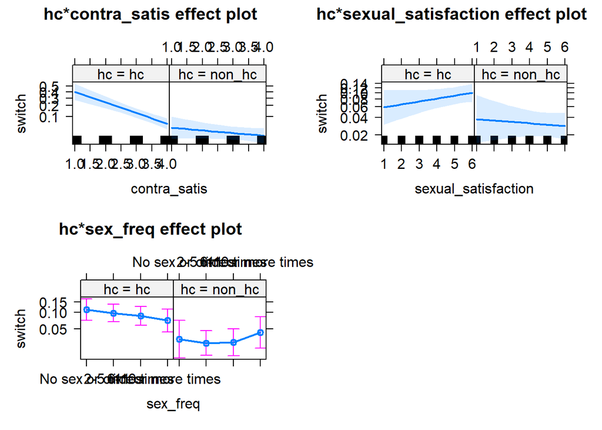

```r
plot(allEffects(m3))
```

##3.4 Model 4: Controlling for observed selection effects

```r
#filter for first measurement occasion
length(unique(cccu_MA$CASEID))
```

```
## [1] 1993
```

```r
cccu_MA_sens = cccu_MA %>%
  group_by(CASEID) %>%
  arrange(WAVE) %>%
  mutate(count = row_number()) %>%
  ungroup()

cccu_MA_sens = cccu_MA_sens %>%
  filter(count == 1)

table(cccu_MA_sens$WAVE)
```

```
##
##   t1   t2   t3   t4
## 1723  201   69    0
```

```r
#repeat model 3 for sensitivity analyses
m3_lm = glm(switch ~ hc * contra_satis + hc * sexual_satisfaction +  hc * sex_freq,
          family = binomial,
          data = cccu_MA_sens)
summary(m3_lm)
```

```
##
## Call:
## glm(formula = switch ~ hc * contra_satis + hc * sexual_satisfaction +
##     hc * sex_freq, family = binomial, data = cccu_MA_sens)
##
## Deviance Residuals:
##     Min       1Q   Median       3Q      Max
## -1.2253  -0.5522  -0.4737  -0.3981   2.3644
##
## Coefficients:
##                                     Estimate Std. Error z value      Pr(>|z|)
## (Intercept)                        0.6672860  0.4751460   1.404       0.16021
## hcnon_hc                          -2.8333714  0.8777340  -3.228       0.00125
## contra_satis                      -0.6213445  0.1053273  -5.899 0.00000000365
## sexual_satisfaction                0.0856086  0.0709763   1.206       0.22776
## sex_freq2-5 times                 -0.4990969  0.2175569  -2.294       0.02178
## sex_freq6-10 times                -0.4476940  0.2397624  -1.867       0.06187
## sex_freq11 or more times          -0.6637965  0.2723131  -2.438       0.01478
## hcnon_hc:contra_satis              0.5012161  0.1901959   2.635       0.00841
## hcnon_hc:sexual_satisfaction       0.0003284  0.1365074   0.002       0.99808
## hcnon_hc:sex_freq2-5 times         0.2074377  0.4556805   0.455       0.64895
## hcnon_hc:sex_freq6-10 times        0.0831579  0.5026310   0.165       0.86859
## hcnon_hc:sex_freq11 or more times  0.5821329  0.5605698   1.038       0.29905
##
## (Intercept)
## hcnon_hc                          **
## contra_satis                      ***
## sexual_satisfaction
## sex_freq2-5 times                 *
## sex_freq6-10 times                .
## sex_freq11 or more times          *
## hcnon_hc:contra_satis             **
## hcnon_hc:sexual_satisfaction
## hcnon_hc:sex_freq2-5 times
## hcnon_hc:sex_freq6-10 times
## hcnon_hc:sex_freq11 or more times
## ---
## Signif. codes:  0 '***' 0.001 '**' 0.01 '*' 0.05 '.' 0.1 ' ' 1
##
## (Dispersion parameter for binomial family taken to be 1)
##
##     Null deviance: 1632.2  on 1992  degrees of freedom
## Residual deviance: 1549.9  on 1981  degrees of freedom
## AIC: 1573.9
##
## Number of Fisher Scoring iterations: 5
```

```r
(m3_lm$coefficients)
```

```
##                       (Intercept)                          hcnon_hc
##                      0.6672859792                     -2.8333713883
##                      contra_satis               sexual_satisfaction
##                     -0.6213445352                      0.0856085523
##                 sex_freq2-5 times                sex_freq6-10 times
##                     -0.4990969129                     -0.4476939653
##          sex_freq11 or more times             hcnon_hc:contra_satis
##                     -0.6637964885                      0.5012161397
##      hcnon_hc:sexual_satisfaction        hcnon_hc:sex_freq2-5 times
##                      0.0003284285                      0.2074376537
##       hcnon_hc:sex_freq6-10 times hcnon_hc:sex_freq11 or more times
##                      0.0831579077                      0.5821329290
```

```r
confint(m3_lm, method = "Wald", level = .997)
```

```
## Es wird auf das Profilieren gewartet ...
```

```
##                                         0.2 %     99.8 %
## (Intercept)                       -0.76508358  2.0658287
## hcnon_hc                          -5.56670395 -0.3261341
## contra_satis                      -0.93583515 -0.3076112
## sexual_satisfaction               -0.12039605  0.3022120
## sex_freq2-5 times                 -1.13943623  0.1573529
## sex_freq6-10 times                -1.15971433  0.2695555
## sex_freq11 or more times          -1.48449548  0.1404396
## hcnon_hc:contra_satis             -0.05170521  1.0821809
## hcnon_hc:sexual_satisfaction      -0.39201233  0.4231736
## hcnon_hc:sex_freq2-5 times        -1.08699049  1.6665589
## hcnon_hc:sex_freq6-10 times       -1.37653467  1.6555178
## hcnon_hc:sex_freq11 or more times -1.08652201  2.2963137
```

```r
m4_lm = glm(switch ~ hc * contra_satis + hc * sexual_satisfaction +  hc * sex_freq + hc *AGE + hc *DEGREE_recode +
              hc *POVRATE +
              hc *HLTHPROB_recode + hc *MEDPROB_recode +  hc *GAPINS_recode +
              hc *TYPEINS_recode + hc *NKIDS_t1 +  hc *pregnant_between_waves + hc *had_baby_between_waves+ hc *Avoid_r +
              hc *FEELPG_recode +
              hc *rel_dur_factor,
            family = binomial,
            data = cccu_MA_sens)
summary(m4_lm)
```

```
##
## Call:
## glm(formula = switch ~ hc * contra_satis + hc * sexual_satisfaction +
##     hc * sex_freq + hc * AGE + hc * DEGREE_recode + hc * POVRATE +
##     hc * HLTHPROB_recode + hc * MEDPROB_recode + hc * GAPINS_recode +
##     hc * TYPEINS_recode + hc * NKIDS_t1 + hc * pregnant_between_waves +
##     hc * had_baby_between_waves + hc * Avoid_r + hc * FEELPG_recode +
##     hc * rel_dur_factor, family = binomial, data = cccu_MA_sens)
##
## Deviance Residuals:
##     Min       1Q   Median       3Q      Max
## -2.0597  -0.5627  -0.3956  -0.2163   3.3393
##
## Coefficients: (1 not defined because of singularities)
##                                                             Estimate
## (Intercept)                                              -10.7113947
## hcnon_hc                                                  -2.0360582
## contra_satis                                              -0.5906671
## sexual_satisfaction                                        0.0740298
## sex_freq2-5 times                                         -0.5543285
## sex_freq6-10 times                                        -0.4117843
## sex_freq11 or more times                                  -0.7894012
## AGE                                                        0.0166049
## DEGREE_recode5th/6th grade                                12.2264124
## DEGREE_recode7th/8th grade                                12.4976589
## DEGREE_recode9th grade                                    -2.8398801
## DEGREE_recode10th grade                                   13.7034155
## DEGREE_recode11th grade                                   12.0629286
## DEGREE_recode12th grade / no diploma                      13.2979663
## DEGREE_recodehigh school diploma or equivalent            12.8559992
## DEGREE_recodesome college, no degree                      12.8888702
## DEGREE_recodeassociate degree                             12.1490440
## DEGREE_recodebachelors degree                             12.7471158
## DEGREE_recodemasters degree                               12.8631447
## DEGREE_recodeprofessional or doctoral degree              13.0261282
## POVRATE                                                   -0.0004501
## HLTHPROB_recodeYes                                         0.0960338
## MEDPROB_recodeYes                                         -0.1758847
## GAPINS_recodeYes                                          -0.2977775
## TYPEINS_recodeYes                                         -0.5341830
```

[output cut: 188 more lines]

```
## hcnon_hc:FEELPG_recode                                      0.005715 **
## hcnon_hc:rel_dur_factor0q-25q                               0.294834
## hcnon_hc:rel_dur_factor26q-50q                              0.065011 .
## hcnon_hc:rel_dur_factor51q-75q                              0.531304
## hcnon_hc:rel_dur_factor76q-100q                             0.612698
## ---
## Signif. codes:  0 '***' 0.001 '**' 0.01 '*' 0.05 '.' 0.1 ' ' 1
##
## (Dispersion parameter for binomial family taken to be 1)
##
##     Null deviance: 1632.2  on 1992  degrees of freedom
## Residual deviance: 1376.9  on 1922  degrees of freedom
## AIC: 1518.9
##
## Number of Fisher Scoring iterations: 15
```

```r
(m4_lm$coefficients)
```

```
##                                             (Intercept)
##                                         -10.71139464556
##                                                hcnon_hc
##                                          -2.03605819705
##                                            contra_satis
##                                          -0.59066710378
##                                     sexual_satisfaction
##                                           0.07402975506
##                                       sex_freq2-5 times
##                                          -0.55432847843
##                                      sex_freq6-10 times
##                                          -0.41178433595
##                                sex_freq11 or more times
##                                          -0.78940120210
##                                                     AGE
##                                           0.01660485969
##                              DEGREE_recode5th/6th grade
##                                          12.22641234898
##                              DEGREE_recode7th/8th grade
##                                          12.49765893004
##                                  DEGREE_recode9th grade
##                                          -2.83988009354
##                                 DEGREE_recode10th grade
##                                          13.70341547068
##                                 DEGREE_recode11th grade
##                                          12.06292863584
##                    DEGREE_recode12th grade / no diploma
##                                          13.29796626790
##          DEGREE_recodehigh school diploma or equivalent
##                                          12.85599922665
##                    DEGREE_recodesome college, no degree
##                                          12.88887015482
##                           DEGREE_recodeassociate degree
##                                          12.14904395567
##                           DEGREE_recodebachelors degree
##                                          12.74711576778
##                             DEGREE_recodemasters degree
##                                          12.86314465213
##            DEGREE_recodeprofessional or doctoral degree
##                                          13.02612815550
```

[output cut: 89 more lines]

```
##                                         -14.22558425248
##                      hcnon_hc:had_baby_between_wavesYes
##                                          12.76686490532
##                                        hcnon_hc:Avoid_r
##                                           0.51305034460
##                                  hcnon_hc:FEELPG_recode
##                                          -0.36611934189
##                           hcnon_hc:rel_dur_factor0q-25q
##                                          -0.47447155755
##                          hcnon_hc:rel_dur_factor26q-50q
##                                          -1.00782754317
##                          hcnon_hc:rel_dur_factor51q-75q
##                                          -0.34186098564
##                         hcnon_hc:rel_dur_factor76q-100q
##                                           0.33997498416
```

```r
(confint(m4_lm, parm = c("(Intercept)",
                                               "hcnon_hc",
                                               "contra_satis",
                                               "sexual_satisfaction",
                                               "sex_freq2-5 times", "sex_freq6-10 times",
                                               "sex_freq11 or more times",
                                               "hcnon_hc:contra_satis",
                                               "hcnon_hc:sexual_satisfaction",
                                               "hcnon_hc:sex_freq2-5 times",
                                               "hcnon_hc:sex_freq6-10 times",
                                               "hcnon_hc:sex_freq11 or more times", "hcnon_hc:Avoid_r", "Avoid_r"), method = "Wald", level = .997))
```

```
## Es wird auf das Profilieren gewartet ...
```

[output not shown]

[output cut: 31 more lines]

[output not shown]

[output not shown]

[output cut: 19 more lines]

[output not shown]

```
##                                         0.2 %       99.8 %
## (Intercept)                                NA 827.84665797
## hcnon_hc                          -8.54574213   4.35531811
## contra_satis                      -0.93463148  -0.24820333
## sexual_satisfaction               -0.14654220   0.30393788
## sex_freq2-5 times                 -1.25618390  -0.14852032
## sex_freq6-10 times                -1.18447541   0.14942134
## sex_freq11 or more times          -1.70217869   0.09913291
## hcnon_hc:contra_satis             -0.28217319   0.78287927
## hcnon_hc:sexual_satisfaction      -0.33702500   0.56102538
## hcnon_hc:sex_freq2-5 times        -0.91982854   2.06654347
## hcnon_hc:sex_freq6-10 times       -1.25353286   2.09197356
## hcnon_hc:sex_freq11 or more times -1.00166271   2.69738024
## hcnon_hc:Avoid_r                   0.07063878   0.98663405
## Avoid_r                           -0.55488258  -0.16143170
```

```
## Note:
##   1 value in the hc*DEGREE_recode effect are not estimable
```

[figure not shown]

```r
plot(allEffects(m4_lm))
```

###Average marginal effects ####m1

```r
#average marginal effect
ame <- marginaleffects(m1)
summary(ame)
```

```
##   Term    Contrast  Effect Std. Error z value         Pr(>|z|)    2.5 %
## 1   hc non_hc - hc -0.0759    0.01174  -6.465 0.00000000010154 -0.09891
##     97.5 %
## 1 -0.05289
##
## Model type:  glmerMod
## Prediction type:  response
```

####m2

```r
#average marginal effect
ame <- marginaleffects(m2)
summary(ame)
```

```
##           Term    Contrast   Effect Std. Error z value              Pr(>|z|)
## 1           hc non_hc - hc -0.08805   0.011210  -7.855 0.0000000000000039964
## 2 contra_satis       dY/dX -0.04624   0.007264  -6.366 0.0000000001941039572
##      2.5 %   97.5 %
## 1 -0.11003 -0.06608
## 2 -0.06048 -0.03201
##
## Model type:  glmerMod
## Prediction type:  response
```

```r
m2_hc_only <- glmer(switch ~ contra_satis + (1| CASEID),
                    family = binomial,
                    data = cccu_MA %>% filter(hc == "hc"),
                    control=glmerControl(optimizer="bobyqa"))
ame <- marginaleffects(m2_hc_only)
summary(ame)
```

```
##           Term   Effect Std. Error z value           Pr(>|z|)    2.5 %   97.5 %
## 1 contra_satis -0.07379     0.0106  -6.963 0.0000000000033308 -0.09456 -0.05302
##
## Model type:  glmerMod
## Prediction type:  response
```

```r
m2_nonhc_only <- glmer(switch ~ contra_satis + (1| CASEID),
                    family = binomial,
                    data = cccu_MA %>% filter(hc == "non_hc"),
                    control=glmerControl(optimizer="bobyqa"))
ame <- marginaleffects(m2_nonhc_only)
summary(ame)
```

```
##           Term   Effect Std. Error z value Pr(>|z|)    2.5 %  97.5 %
## 1 contra_satis -0.00113   0.005541  -0.204  0.83835 -0.01199 0.00973
##
## Model type:  glmerMod
## Prediction type:  response
```

####m3

```r
#average marginal effect
ame <- marginaleffects(m3)
summary(ame)
```

```
##                  Term                          Contrast    Effect Std. Error
## 1                  hc                       non_hc - hc -0.087475   0.011293
## 2        contra_satis                             dY/dX -0.046608   0.007330
## 3 sexual_satisfaction                             dY/dX  0.005733   0.004623
## 4            sex_freq        2-5 times - No sex or once -0.012631   0.016365
## 5            sex_freq       6-10 times - No sex or once -0.018575   0.017718
## 6            sex_freq 11 or more times - No sex or once -0.021238   0.019448
##   z value              Pr(>|z|)     2.5 %   97.5 %
## 1 -7.7457 0.0000000000000095047 -0.109610 -0.06534
## 2 -6.3587 0.0000000002035142052 -0.060975 -0.03224
## 3  1.2401               0.21493 -0.003328  0.01479
## 4 -0.7719               0.44019 -0.044706  0.01944
## 5 -1.0484               0.29447 -0.053301  0.01615
## 6 -1.0920               0.27482 -0.059356  0.01688
##
## Model type:  glmerMod
## Prediction type:  response
```

```r
m3_hc_only <- glmer(switch ~ contra_satis + sexual_satisfaction + sex_freq +
                      (1| CASEID),
                    family = binomial,
                    data = cccu_MA %>% filter(hc == "hc"),
                    control=glmerControl(optimizer="bobyqa"))
ame <- marginaleffects(m3_hc_only)
summary(ame)
```

```
##                  Term                          Contrast   Effect Std. Error
## 1        contra_satis                             dY/dX -0.07482   0.010652
## 2 sexual_satisfaction                             dY/dX  0.01105   0.006958
## 3            sex_freq        2-5 times - No sex or once -0.01247   0.024169
## 4            sex_freq       6-10 times - No sex or once -0.02799   0.025830
## 5            sex_freq 11 or more times - No sex or once -0.04479   0.027455
##   z value           Pr(>|z|)     2.5 %   97.5 %
## 1 -7.0240 0.0000000000021559 -0.095699 -0.05394
## 2  1.5882            0.11225 -0.002587  0.02469
## 3 -0.5159            0.60594 -0.059839  0.03490
## 4 -1.0836            0.27853 -0.078615  0.02264
## 5 -1.6314            0.10280 -0.098603  0.00902
##
## Model type:  glmerMod
## Prediction type:  response
```

```r
m3_nonhc_only <- glmer(switch ~ contra_satis + sexual_satisfaction + sex_freq +
                      (1| CASEID),
                    family = binomial,
                    data = cccu_MA %>% filter(hc == "non_hc"),
                    control=glmerControl(optimizer="bobyqa"))
ame <- marginaleffects(m3_nonhc_only)
summary(ame)
```

```
##                  Term                          Contrast     Effect Std. Error
## 1        contra_satis                             dY/dX -0.0005486   0.005603
## 2 sexual_satisfaction                             dY/dX -0.0022447   0.003912
## 3            sex_freq        2-5 times - No sex or once -0.0155492   0.012345
## 4            sex_freq       6-10 times - No sex or once -0.0137694   0.014192
## 5            sex_freq 11 or more times - No sex or once  0.0004431   0.012111
##    z value Pr(>|z|)     2.5 %   97.5 %
## 1 -0.09791  0.92200 -0.011531 0.010434
## 2 -0.57382  0.56609 -0.009912 0.005422
## 3 -1.25955  0.20783 -0.039745 0.008647
## 4 -0.97023  0.33193 -0.041585 0.014046
## 5  0.03659  0.97081 -0.023293 0.024180
##
## Model type:  glmerMod
## Prediction type:  response
```

####m4

```r
#average marginal effect

#model 3 lm
ame <- marginaleffects(m3_lm)
summary(ame)
```

```
##                  Term                          Contrast    Effect Std. Error
## 1                  hc                       non_hc - hc -0.109403   0.015568
## 2        contra_satis                             dY/dX -0.056032   0.009972
## 3 sexual_satisfaction                             dY/dX  0.009976   0.007058
## 4            sex_freq        2-5 times - No sex or once -0.056942   0.026321
## 5            sex_freq       6-10 times - No sex or once -0.054948   0.028351
## 6            sex_freq 11 or more times - No sex or once -0.062362   0.030842
##   z value           Pr(>|z|)     2.5 %     97.5 %
## 1  -7.027 0.0000000000021043 -0.139916 -0.0788903
## 2  -5.619 0.0000000192105576 -0.075577 -0.0364874
## 3   1.413           0.157560 -0.003858  0.0238100
## 4  -2.163           0.030513 -0.108529 -0.0053539
## 5  -1.938           0.052611 -0.110515  0.0006198
## 6  -2.022           0.043180 -0.122812 -0.0019122
##
## Model type:  glm
## Prediction type:  response
```

```r
#model 4
ame <- marginaleffects(m4_lm)
summary(ame)
```

```
##                      Term                                             Contrast
## 1                      hc                                          non_hc - hc
## 2            contra_satis                                                dY/dX
## 3     sexual_satisfaction                                                dY/dX
## 4                sex_freq                           2-5 times - No sex or once
## 5                sex_freq                          6-10 times - No sex or once
## 6                sex_freq                    11 or more times - No sex or once
## 7                     AGE                                                dY/dX
## 8           DEGREE_recode                     5th/6th grade - 1st to 4th grade
## 9           DEGREE_recode                     7th/8th grade - 1st to 4th grade
## 10          DEGREE_recode                         9th grade - 1st to 4th grade
## 11          DEGREE_recode                        10th grade - 1st to 4th grade
## 12          DEGREE_recode                        11th grade - 1st to 4th grade
## 13          DEGREE_recode           12th grade / no diploma - 1st to 4th grade
## 14          DEGREE_recode high school diploma or equivalent - 1st to 4th grade
```

[output cut: 99 more lines]

```r
m4_hc_only <- glm(switch ~ contra_satis + sexual_satisfaction +  sex_freq +
                    AGE + DEGREE_recode + POVRATE +
                    HLTHPROB_recode + MEDPROB_recode +  GAPINS_recode +
                    TYPEINS_recode + NKIDS_t1 +  pregnant_between_waves +
                    had_baby_between_waves + Avoid_r + FEELPG_recode +
                    rel_dur_factor,
            family = binomial,
            data = cccu_MA_sens %>% filter(hc == "hc"))

ame <- marginaleffects(m4_hc_only)
summary(ame)
```

```
##                      Term                                          Contrast
## 1            contra_satis                                             dY/dX
## 2     sexual_satisfaction                                             dY/dX
## 3                sex_freq                        2-5 times - No sex or once
## 4                sex_freq                       6-10 times - No sex or once
## 5                sex_freq                 11 or more times - No sex or once
## 6                     AGE                                             dY/dX
## 7           DEGREE_recode                     7th/8th grade - 5th/6th grade
## 8           DEGREE_recode                         9th grade - 5th/6th grade
## 9           DEGREE_recode                        10th grade - 5th/6th grade
## 10          DEGREE_recode                        11th grade - 5th/6th grade
## 11          DEGREE_recode           12th grade / no diploma - 5th/6th grade
## 12          DEGREE_recode high school diploma or equivalent - 5th/6th grade
## 13          DEGREE_recode           some college, no degree - 5th/6th grade
## 14          DEGREE_recode                  associate degree - 5th/6th grade
```

[output cut: 58 more lines]

```r
m4_nonhc_only <- glm(switch ~ contra_satis + sexual_satisfaction +  sex_freq +
                    AGE + DEGREE_recode + POVRATE +
                    HLTHPROB_recode + MEDPROB_recode +  GAPINS_recode +
                    TYPEINS_recode + NKIDS_t1 +  pregnant_between_waves +
                    had_baby_between_waves + Avoid_r + FEELPG_recode +
                    rel_dur_factor,
            family = binomial,
            data = cccu_MA_sens %>% filter(hc == "non_hc"))

ame <- marginaleffects(m4_nonhc_only)
summary(ame)
```

```
##                      Term                                             Contrast
## 1            contra_satis                                                dY/dX
## 2     sexual_satisfaction                                                dY/dX
## 3                sex_freq                           2-5 times - No sex or once
## 4                sex_freq                          6-10 times - No sex or once
## 5                sex_freq                    11 or more times - No sex or once
## 6                     AGE                                                dY/dX
## 7           DEGREE_recode                     5th/6th grade - 1st to 4th grade
## 8           DEGREE_recode                     7th/8th grade - 1st to 4th grade
## 9           DEGREE_recode                         9th grade - 1st to 4th grade
## 10          DEGREE_recode                        10th grade - 1st to 4th grade
## 11          DEGREE_recode                        11th grade - 1st to 4th grade
## 12          DEGREE_recode           12th grade / no diploma - 1st to 4th grade
## 13          DEGREE_recode high school diploma or equivalent - 1st to 4th grade
## 14          DEGREE_recode           some college, no degree - 1st to 4th grade
```

[output cut: 60 more lines]

#4. Senstivity analysis after m4: controlling for unobserved selection effects

```r
#repeat models first

summary(m3_lm)
```

```
##
## Call:
## glm(formula = switch ~ hc * contra_satis + hc * sexual_satisfaction +
##     hc * sex_freq, family = binomial, data = cccu_MA_sens)
##
## Deviance Residuals:
##     Min       1Q   Median       3Q      Max
## -1.2253  -0.5522  -0.4737  -0.3981   2.3644
##
## Coefficients:
##                                     Estimate Std. Error z value      Pr(>|z|)
## (Intercept)                        0.6672860  0.4751460   1.404       0.16021
## hcnon_hc                          -2.8333714  0.8777340  -3.228       0.00125
## contra_satis                      -0.6213445  0.1053273  -5.899 0.00000000365
## sexual_satisfaction                0.0856086  0.0709763   1.206       0.22776
## sex_freq2-5 times                 -0.4990969  0.2175569  -2.294       0.02178
## sex_freq6-10 times                -0.4476940  0.2397624  -1.867       0.06187
## sex_freq11 or more times          -0.6637965  0.2723131  -2.438       0.01478
## hcnon_hc:contra_satis              0.5012161  0.1901959   2.635       0.00841
## hcnon_hc:sexual_satisfaction       0.0003284  0.1365074   0.002       0.99808
## hcnon_hc:sex_freq2-5 times         0.2074377  0.4556805   0.455       0.64895
## hcnon_hc:sex_freq6-10 times        0.0831579  0.5026310   0.165       0.86859
## hcnon_hc:sex_freq11 or more times  0.5821329  0.5605698   1.038       0.29905
##
## (Intercept)
## hcnon_hc                          **
## contra_satis                      ***
## sexual_satisfaction
## sex_freq2-5 times                 *
## sex_freq6-10 times                .
## sex_freq11 or more times          *
## hcnon_hc:contra_satis             **
## hcnon_hc:sexual_satisfaction
## hcnon_hc:sex_freq2-5 times
## hcnon_hc:sex_freq6-10 times
## hcnon_hc:sex_freq11 or more times
## ---
## Signif. codes:  0 '***' 0.001 '**' 0.01 '*' 0.05 '.' 0.1 ' ' 1
##
## (Dispersion parameter for binomial family taken to be 1)
##
##     Null deviance: 1632.2  on 1992  degrees of freedom
## Residual deviance: 1549.9  on 1981  degrees of freedom
## AIC: 1573.9
##
## Number of Fisher Scoring iterations: 5
```

```r
summary(m4_lm)
```

```
##
## Call:
## glm(formula = switch ~ hc * contra_satis + hc * sexual_satisfaction +
##     hc * sex_freq + hc * AGE + hc * DEGREE_recode + hc * POVRATE +
##     hc * HLTHPROB_recode + hc * MEDPROB_recode + hc * GAPINS_recode +
##     hc * TYPEINS_recode + hc * NKIDS_t1 + hc * pregnant_between_waves +
##     hc * had_baby_between_waves + hc * Avoid_r + hc * FEELPG_recode +
##     hc * rel_dur_factor, family = binomial, data = cccu_MA_sens)
##
## Deviance Residuals:
##     Min       1Q   Median       3Q      Max
## -2.0597  -0.5627  -0.3956  -0.2163   3.3393
##
## Coefficients: (1 not defined because of singularities)
##                                                             Estimate
## (Intercept)                                              -10.7113947
## hcnon_hc                                                  -2.0360582
## contra_satis                                              -0.5906671
## sexual_satisfaction                                        0.0740298
## sex_freq2-5 times                                         -0.5543285
## sex_freq6-10 times                                        -0.4117843
## sex_freq11 or more times                                  -0.7894012
## AGE                                                        0.0166049
## DEGREE_recode5th/6th grade                                12.2264124
## DEGREE_recode7th/8th grade                                12.4976589
## DEGREE_recode9th grade                                    -2.8398801
## DEGREE_recode10th grade                                   13.7034155
## DEGREE_recode11th grade                                   12.0629286
## DEGREE_recode12th grade / no diploma                      13.2979663
## DEGREE_recodehigh school diploma or equivalent            12.8559992
## DEGREE_recodesome college, no degree                      12.8888702
## DEGREE_recodeassociate degree                             12.1490440
## DEGREE_recodebachelors degree                             12.7471158
## DEGREE_recodemasters degree                               12.8631447
## DEGREE_recodeprofessional or doctoral degree              13.0261282
## POVRATE                                                   -0.0004501
## HLTHPROB_recodeYes                                         0.0960338
## MEDPROB_recodeYes                                         -0.1758847
## GAPINS_recodeYes                                          -0.2977775
## TYPEINS_recodeYes                                         -0.5341830
```

[output cut: 188 more lines]

```
## hcnon_hc:FEELPG_recode                                      0.005715 **
## hcnon_hc:rel_dur_factor0q-25q                               0.294834
## hcnon_hc:rel_dur_factor26q-50q                              0.065011 .
## hcnon_hc:rel_dur_factor51q-75q                              0.531304
## hcnon_hc:rel_dur_factor76q-100q                             0.612698
## ---
## Signif. codes:  0 '***' 0.001 '**' 0.01 '*' 0.05 '.' 0.1 ' ' 1
##
## (Dispersion parameter for binomial family taken to be 1)
##
##     Null deviance: 1632.2  on 1992  degrees of freedom
## Residual deviance: 1376.9  on 1922  degrees of freedom
## AIC: 1518.9
##
## Number of Fisher Scoring iterations: 15
```

```r
##compute OR and CI first

#model 3 to compare e-value for unobserved / observed confounders
exp(m3_lm$coefficients)
```

```
##                       (Intercept)                          hcnon_hc
##                        1.94894067                        0.05881423
##                      contra_satis               sexual_satisfaction
##                        0.53722164                        1.08937981
##                 sex_freq2-5 times                sex_freq6-10 times
##                        0.60707866                        0.63910024
##          sex_freq11 or more times             hcnon_hc:contra_satis
##                        0.51489283                        1.65072757
##      hcnon_hc:sexual_satisfaction        hcnon_hc:sex_freq2-5 times
##                        1.00032848                        1.23052100
##       hcnon_hc:sex_freq6-10 times hcnon_hc:sex_freq11 or more times
##                        1.08671340                        1.78985199
```

```r
exp(confint(m3_lm, method = "Wald", level = .997))
```

```
## Es wird auf das Profilieren gewartet ...
```

```
##                                         0.2 %    99.8 %
## (Intercept)                       0.465295042 7.8918351
## hcnon_hc                          0.003823061 0.7217084
## contra_satis                      0.392258135 0.7352011
## sexual_satisfaction               0.886569238 1.3528480
## sex_freq2-5 times                 0.319999376 1.1704086
## sex_freq6-10 times                0.313575747 1.3093823
## sex_freq11 or more times          0.226616643 1.1507795
## hcnon_hc:contra_satis             0.949608761 2.9511087
## hcnon_hc:sexual_satisfaction      0.675695785 1.5267993
## hcnon_hc:sex_freq2-5 times        0.337229863 5.2939193
## hcnon_hc:sex_freq6-10 times       0.252451867 5.2357905
## hcnon_hc:sex_freq11 or more times 0.337387888 9.9374818
```

```r
#model 4
exp(m4_lm$coefficients)
```

```
##                                             (Intercept)
##                                         0.0000222895044
##                                                hcnon_hc
##                                         0.1305422699437
##                                            contra_satis
##                                         0.5539576142243
##                                     sexual_satisfaction
##                                         1.0768388464245
##                                       sex_freq2-5 times
##                                         0.5744578925656
##                                      sex_freq6-10 times
##                                         0.6624671309908
##                                sex_freq11 or more times
##                                         0.4541166379723
##                                                     AGE
##                                         1.0167434866003
##                              DEGREE_recode5th/6th grade
##                                    204109.5929630995379
##                              DEGREE_recode7th/8th grade
##                                    267709.8249129809556
##                                  DEGREE_recode9th grade
##                                         0.0584326719991
##                                 DEGREE_recode10th grade
##                                    893959.2492981681135
##                                 DEGREE_recode11th grade
##                                    173325.8513800876681
##                    DEGREE_recode12th grade / no diploma
##                                    595982.3120874912711
##          DEGREE_recodehigh school diploma or equivalent
##                                    383080.0394616120611
##                    DEGREE_recodesome college, no degree
##                                    395881.4809154375107
##                           DEGREE_recodeassociate degree
##                                    188913.3938960440864
##                           DEGREE_recodebachelors degree
##                                    343559.5602090824977
##                             DEGREE_recodemasters degree
##                                    385827.1121506328927
##            DEGREE_recodeprofessional or doctoral degree
##                                    454125.1752802860574
```

[output cut: 89 more lines]

```
##                                         0.0000006636013
##                      hcnon_hc:had_baby_between_wavesYes
##                                    350412.0074585920665
##                                        hcnon_hc:Avoid_r
##                                         1.6703786622680
##                                  hcnon_hc:FEELPG_recode
##                                         0.6934200422119
##                           hcnon_hc:rel_dur_factor0q-25q
##                                         0.6222137737714
##                          hcnon_hc:rel_dur_factor26q-50q
##                                         0.3650110896833
##                          hcnon_hc:rel_dur_factor51q-75q
##                                         0.7104469601750
##                         hcnon_hc:rel_dur_factor76q-100q
##                                         1.4049124450593
```

```r
exp(confint(m4_lm, parm = "contra_satis", method = "Wald", level = .997))
```

```
## Es wird auf das Profilieren gewartet ...
```

```
##     0.2 %    99.8 %
## 0.3927306 0.7802013
```

```r
exp(confint(m4_lm, parm = "hcnon_hc:contra_satis", method = "Wald", level = .997))
```

```
## Es wird auf das Profilieren gewartet ...
```

```
##     0.2 %    99.8 %
## 0.7541431 2.1877624
```

```r
exp(confint(m4_lm, parm = "hcnon_hc", method = "Wald", level = .997))
```

```
## Es wird auf das Profilieren gewartet ...
```

```
##         0.2 %        99.8 %
##  0.0001943709 77.8915992173
```

```r
#compute e-values

#model 3

#for contra_satis
evalue(OR(0.53722164,rare=FALSE),lo= 0.392258135,  hi=0.7352011)
```

```
##              point     lower     upper
## RR       0.7329541 0.6263051 0.8574387
## E-values 2.0693861        NA 1.6066139
```

```r
#for contra_satis*hc
evalue(OR(1.65072757,rare=FALSE),lo= 0.949608761,  hi=2.9511087)
```

```
## Confidence interval crosses the true value, so its E-value is 1.
```

```
##             point     lower    upper
## RR       1.284806 0.9744787 1.717879
## E-values 1.889721 1.0000000       NA
```

```r
#for hc
evalue(OR(0.05881423,rare=FALSE),lo= 0.003823061,  hi=0.7217084)
```

```
##              point      lower     upper
## RR       0.2425165 0.06183091 0.8495342
## E-values 7.7121997         NA 1.6337178
```

```r
#model 4
#for contra_satis
evalue(OR(0.5539576142243,rare=FALSE),lo= 0.3927306,  hi=0.7802013)
```

```
##              point     lower    upper
## RR       0.7442833 0.6266822 0.883290
## E-values 2.0229991        NA 1.518899
```

```r
#for contra_satis * hc
evalue(OR(1.387322e+00,rare=FALSE),lo= 0.7541431,  hi=2.1877624)
```

```
## Confidence interval crosses the true value, so its E-value is 1.
```

```
##             point     lower    upper
## RR       1.177846 0.8684141 1.479109
## E-values 1.635531 1.0000000       NA
```

```r
#for hc
evalue(OR(0.1305422699437,rare=FALSE),lo= 0.0001943709,  hi=77.8915992173)
```

```
## Confidence interval crosses the true value, so its E-value is 1.
```

```
##              point     lower    upper
## RR       0.3613063 0.0139417 8.825622
## E-values 4.9796611        NA 1.000000
```